# Ecopop Interativa

Gabriel Santos https://ecosantos.netlify.app/ (Instituto Nacional da Mata Atlântica)http://inma.gov.br/ , Nathalia Hohl http://lattes.cnpq.br/4836698360243899 (Universidade do Estado do Rio de Janeiro)https://www.uerj.br/  
2022-08-02

## SOBRE

O app **Ecopop Interativa** é uma tentativa de fornecer uma plataforma interativa como recurso didático adicional aos livros utilizados na disciplina de ecologia, mais especificamente em ecologia de populações. Através do app, os estudantes podem realizar simulações para explorar os mecanismos e resultados dos modelos populacionais, que muitas vezes parecem complexos e abstratos. Esperamos que ao simular diversos cenários possíveis, os estudantes possam ter uma experiência divertida com a matemática por trás desses modelos.

**Ecopop Interativa** é uma proposta desenvolvida por Nathalia Hohl e Gabriel Santos e foi desenvolvido utilizando R + Shiny. Assim como o [Software R](https://cran.r-project.org/), o app Ecologia interativa possui código aberto e colaborações são muito bem vindas. Por ser construído com base numa linguagem de programação tão frequentemente utilizada entre ecólogos, esperamos que o app possa aumentar suas funcionalidades rapidamente graças a um esforço coletivo e se tornar uma grande referência em termos de material didático no ensino de ecologia.

## COMO CONTRIBUIR

Para contribuir com o aplicativo você pode enviar sua sugestão por email, ou propor diretamente através do nosso [Github](https://github.com/ecopopr/ecopopr-app) onde o código está disponível.

## LICENÇA

Publicado sob a licença Atribuição-NãoComercial-CompartilhaIgual 4.0 Internacional.

Confira as regras de reprodução e modificação: [CC BY-NC-SA 4.0](https://creativecommons.org/licenses/by-nc-sa/4.0/deed.pt)

## AUTORES

#### Nathália Hohl

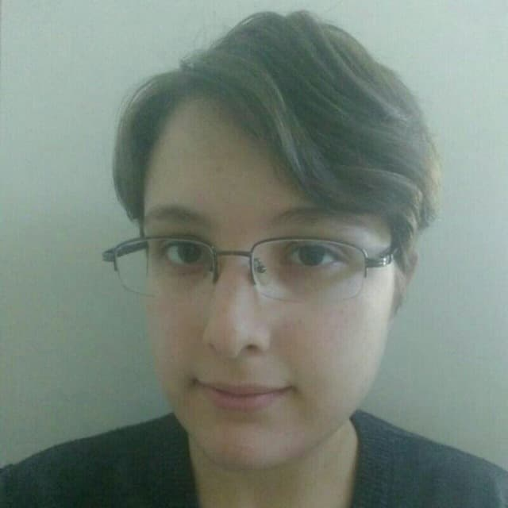

**Nathália** é graduanda em Ciências Biológicas pela Universidade do Estado do Rio de Janeiro. Tem interesse pelo uso da programação e estatística na Ecologia, sobretudo na área de Ecologia de Populações. Objetiva contribuir para que novos biólogos aprendam a disciplina com mais facilidade e eficácia. Você pode saber mais através do [Lattes](http://lattes.cnpq.br/4836698360243899) ou mandar um email.

#### Gabriel Santos

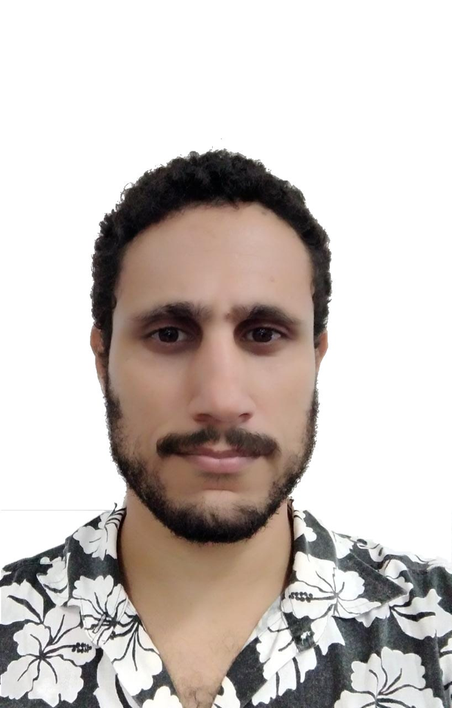

**Gabriel** atualmente é pesquisador vinculado ao Instituto Nacional da Mata Atlântica. Tem interesse em diversas linhas de pesquisa que envolvam o uso de estatística, teoria e o envolvimento da comunidade local, entre elas análise de viabilidade populacional em vida livre, evolução da história de vida dos organismos, proposta de manejo de espécies exóticas e ameaçadas e ciência cidadã. Você pode acompanhar mais sobre os projetos desenvolvidos através do [site](https://ecosantos.netlify.app/), [Lattes](http://lattes.cnpq.br/1714610835853424), ou mande um email.